# TP Biodiversité-Concentration n°1

2023-06-19

# Packages

Installation des packages nécessaires.

```r
InstallPackages <- function(Packages) {
  InstallPackage <- function(Package) {
    if (!Package %in% installed.packages()[, 1]) {
      install.packages(Package, repos="https://cran.rstudio.com/")
    }
  }
  invisible(sapply(Packages, InstallPackage))
}

# Basic packages
InstallPackages(c("entropart", "dbmss"))
```

```
##
##  /var/folders/24/8k48jl6d249_n_qfxwsl6xvm0000gn/T//Rtmp15hGJl/downloaded_packages
```

# Données Eurostat

## Lecture

Les données d’[Eurostat](https://ec.europa.eu/eurostat/web/regions/data/database/) fournissent le nombre nombre d’employés par secteur industriel dans vingt-cinq pays européens en 2015 (*SBS data by NUTS 2 regions and NACE Rev.2*).

Les pays avec trop de données manquantes sont supprimés, de même que les secteurs incomplètement renseignés.

```r
EuroStat <- read.csv2(file = "data/sbs_r_nuts06_r2.csv")
# Suppression des pays avec trop de données manquantes
EuroStat <- EuroStat[
  !(substr(EuroStat$geo, start = 1, stop = 2) %in% c("CY", "IE", "LU", "MT", "SI")),
]
# Mise à jour du facteur
EuroStat$geo <- factor(EuroStat$geo)
# n2015 est importé comme chaîne de caractères : conversion
EuroStat$n2015 <- as.numeric(EuroStat$n2015)
# Niveau de détail
NUTS0 <- nchar(as.character(EuroStat$geo)) == 2
NUTS1 <- nchar(as.character(EuroStat$geo)) == 3
NUTS2 <- nchar(as.character(EuroStat$geo)) == 4
NACE1 <- nchar(as.character(EuroStat$nace_r2)) == 1
NACE2 <- nchar(as.character(EuroStat$nace_r2)) == 3
NACE3 <- nchar(as.character(EuroStat$nace_r2)) == 4

# Sélection des données
ES02C <- EuroStat[
  # NUTS et NACE
  NUTS0 & NACE2 &
    # Industrie
    substr(EuroStat$nace_r2, start = 1, stop = 1) == "C",
]
# Tableau de contingence
xtab <- as.data.frame.matrix(
  xtabs(n2015 ~ nace_r2 + geo,
  data = ES02C,
  addNA = TRUE,
  drop.unused.levels = TRUE)
)
# Elimination des secteurs avec données manquantes
ES02Cx <- xtab[apply(xtab, 1, function(x) !any(is.na(x))), ]
```

Le résultat est un tableau avec les secteurs en ligne et les pays en colonnes.

```r
ES02Cx[1:4, 1:6]
```

```
##        AT    BE    BG     CZ     DE    DK
## C10 71924 85083 82510 101575 591468 54896
## C11  9319  9814 13298  15301  71327  4523
## C13  8665 17329 12914  25983  73448  3951
## C14  6212  3495 99974  25717  35275  1611
```

## Diversité de l’industrie française

Les données sont peu détaillées, avec 19 secteurs industriels.

La distribution des abondances peut être représentée par un diagramme Rang-abondance (“Whittaker plot” en écologie).

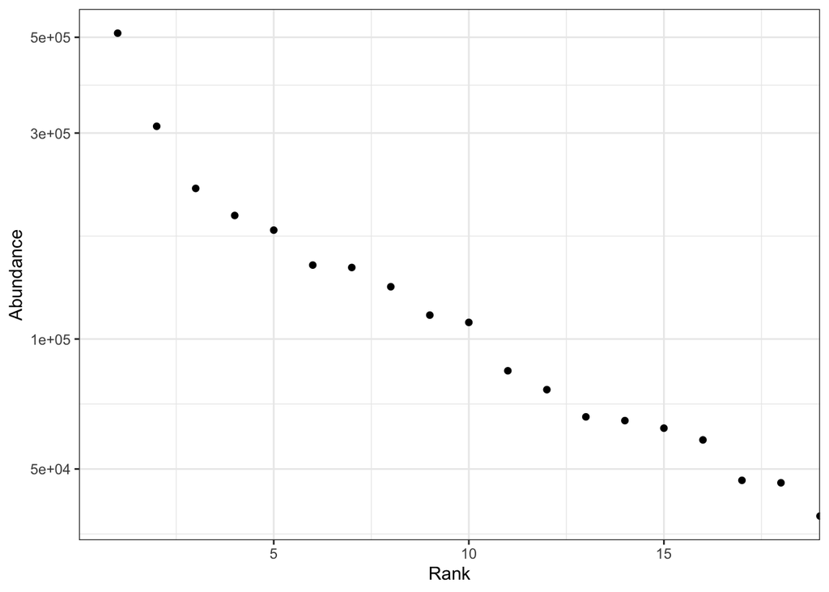

```r
library("entropart")
# Déclaration explicite du type de données
France <- as.AbdVector(ES02Cx["FR"])
autoplot(France)
```

### Richesse

La richesse est de 19 secteurs.

```r
Richness(France)
```

```
## Jackknife 10
##           19
```

### Entropie de Shannon

```r
Shannon(France)
```

```
##  UnveilJ
## 2.683118
```

Nombre de Hill correspondant :

```r
Diversity(France, q = 1)
```

```
##  UnveilJ
## 14.63064
```

### Entropie de Simpson

Probabilité que deux employés choisis au hasard travaillent dans deux secteurs différents (complément à 1 de l’indice d’Herfindahl).

```r
Simpson(France)
```

```
##     Lande
## 0.9123962
```

Nombre de Hill correspondant :

```r
Diversity(France, q = 2)
```

```
##  UnveilJ
## 11.41499
```

### Profil de diversité

Nombre effectif de secteurs industriels en fonction de l’ordre de la diversité :

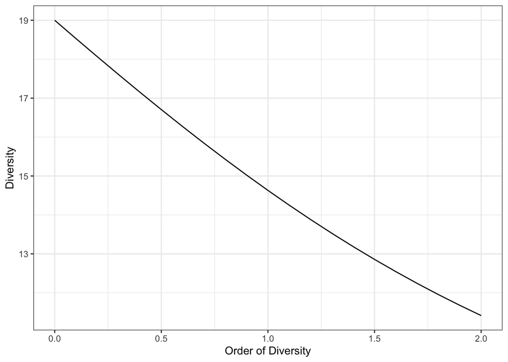

```r
autoplot(CommunityProfile(Diversity, France))
```

Comparaison avec l’Italie

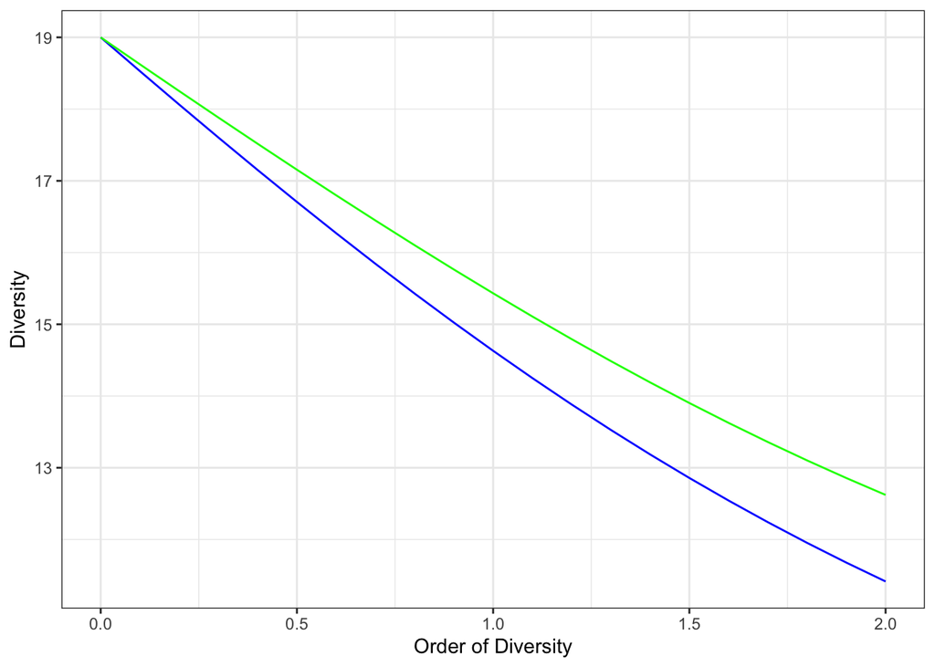

```r
France_dp <- CommunityProfile(Diversity, France)
Italie_dp <- CommunityProfile(Diversity, as.AbdVector(ES02Cx["IT"]))
library("ggplot2")
autoplot(France_dp, col = "blue") +
  geom_line(
    data = as.data.frame.list(Italie_dp),
    mapping = aes(x = x, y = y),
    col = "green"
  )
```

# Forêt de Barro Colorado Island

Les données sont dans le package *vegan*

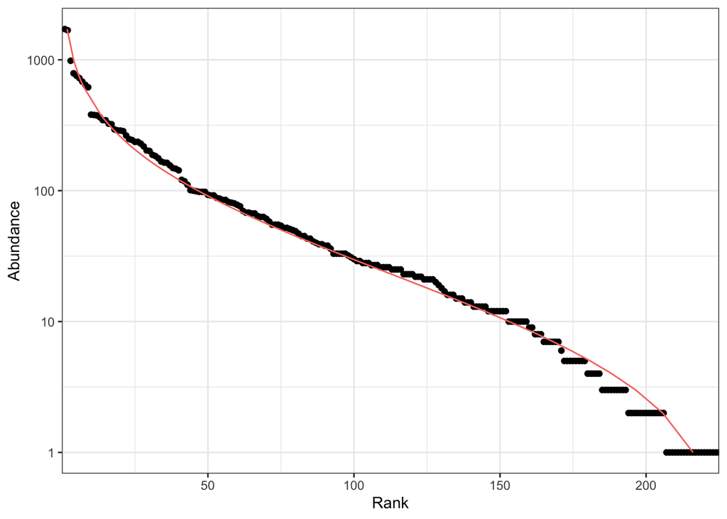

```r
library("vegan")
data("BCI")
# Somme des 50 hectares
BCI_50 <- as.AbdVector(colSums(BCI))
autoplot(BCI_50, Distribution = "lnorm")
```

## Estimation de la diversité

En écologie, les données sont généralement des échantillons : ici, 50 ha d’une forêt de plusieurs centaines de km<sup>2</sup>.

La diversité observée augmente avec l’effort d’échantillonnage. La figure suivante montre l’espérance du nombre d’espèces échantillonnées en fonction du nombre d’arbres.

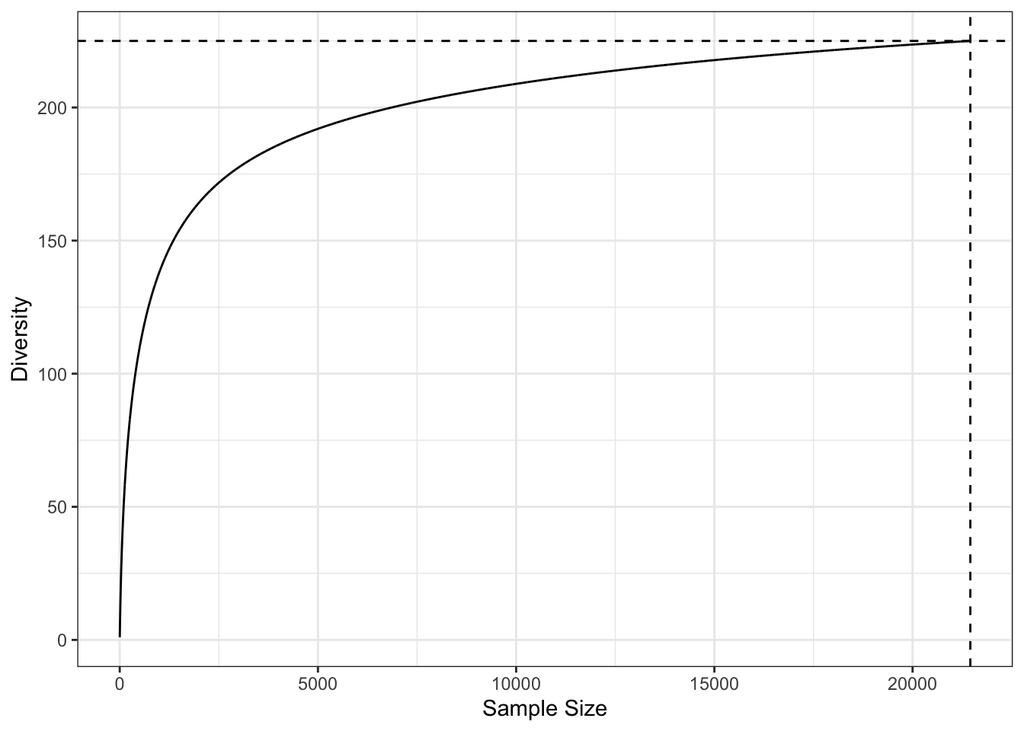

```r
# Species Accumulation Curve
autoplot(DivAC(BCI_50))
```

Il est possible d’estimer la diversité asymptotique par des techniques statistiques.

```r
Richness(BCI_50)
```

```
## Jackknife 1
##         244
```

La différence entre la diversité asymptotique et la diversité observée est d’autant plus grande que l’ordre de la diversité est petit.

La diversité de Simpson est peu sensible au sous-échantillonnage.

```r
# Diversité observée
Diversity(BCI_50, Correction = "None", q = 2)
```

```
##     None
## 37.98748
```

```r
# Diversité estimée
Diversity(BCI_50, q = 2)
```

```
##  UnveilJ
## 38.05234
```

## Profil de diversité

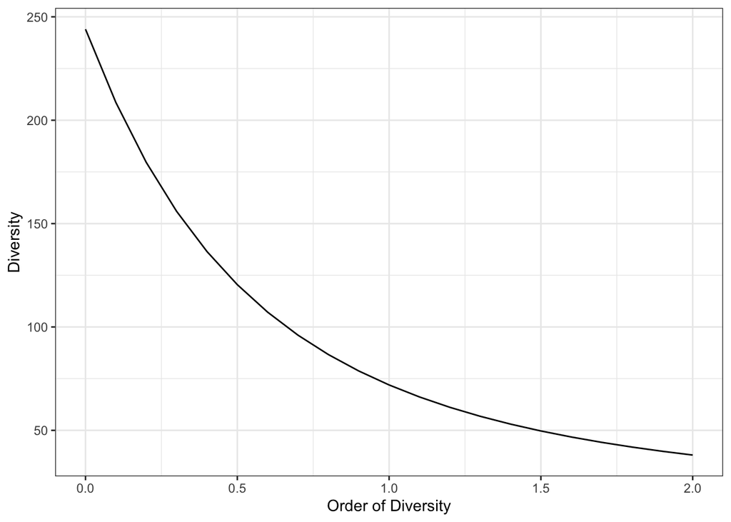

```r
autoplot(CommunityProfile(Diversity, BCI_50))
```